# Reproducible Research: Peer Assessment 1

## Loading and preprocessing the data

- Load the data from csv file

```r
  if(!file.exists('activity.csv')){
    unzip('activity.zip')
  }
  activityData <- read.csv('activity.csv')
```

- Process the input data into POSIX date format

```r
  activityData$date <- as.POSIXct(strptime(activityData$date, "%Y-%m-%d"), tz="")
  activityData$time <- sprintf("%04d", activityData$interval)
  activityData$time <- as.POSIXct(activityData$time, "%H%M", tz="")
```

## What is mean total number of steps taken per day?

- Aggregate the data into a new data frame containing the total number of steps per day

```r
  totalStepsByDay <- aggregate(list(total_steps = activityData$steps), by = list(date = activityData$date), FUN = sum, na.rm = TRUE)
```

- Histogram of total steps per day

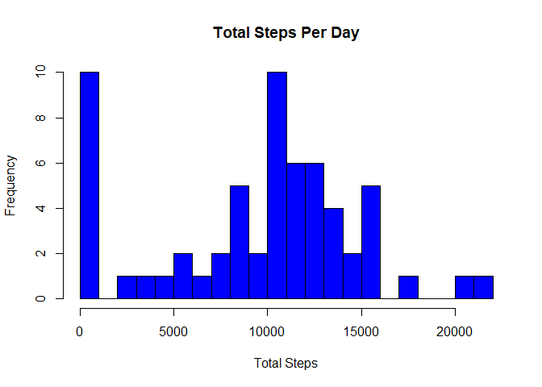

```r
  hist(totalStepsByDay$total_steps,
     breaks=30,
     xlab="Total Steps",
     main="Total Steps Per Day",
     col="blue")
```

- Calculate the mean and median number of steps per day

```r
  stepsByDayMean <- mean(totalStepsByDay$total_steps)
  stepsByDayMedian <- median(totalStepsByDay$total_steps, na.rm = TRUE)
```

The Mean is : 9354.2295082 and the Median is : 10395

## What is the average daily activity pattern?

- Aggregate the average number of steps for each time interval

```r
  averageStepsByTime <- aggregate(list(average_steps = activityData$steps),
      by = list(time = activityData$time,
      interval = activityData$interval),
      FUN = mean,
      na.rm = TRUE)
```

- Make a time series plot

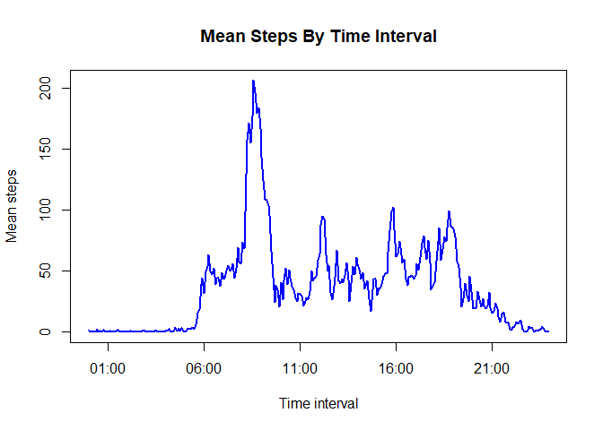

```r
  plot(average_steps ~ time,
      data = averageStepsByTime,
      xlab = "Time interval",
      ylab = "Mean steps",
      main = "Mean Steps By Time Interval",
      type = "l",
      col = "blue",
      lwd = 2)
```

- Determine the interval with the maximum average number of steps

```r
    timeMostSteps <- gsub("([0-9]{1,2})([0-9]{2})", "\\1:\\2",
        averageStepsByTime[which.max(averageStepsByTime$average_steps),'interval'])
```

Most Steps are at : 8:35

## Imputing missing values

- Calculate and report the total number of missing values in the dataset

```r
  numMissingValues <- length(which(is.na(activityData$steps)))
```

Number of missing values : 2304

- Use the average number of steps for the time interval to fill in all of the missing values

```r
    activityNew <- merge(activityData, averageStepsByTime, by = "interval")
    activityNew <- within(activityNew,
        steps <- ifelse(is.na(activityNew$steps),
        activityNew$average_steps,
        activityNew$steps))
```

- Calculate the total number of steps per day with the new values

```r
    totalStepsByDayNew <- aggregate(list(total_steps = activityNew$steps),
        by = list(date = activityNew$date),
        FUN = sum,
        na.rm = FALSE)
```

- Histogram of total steps per day for the new values

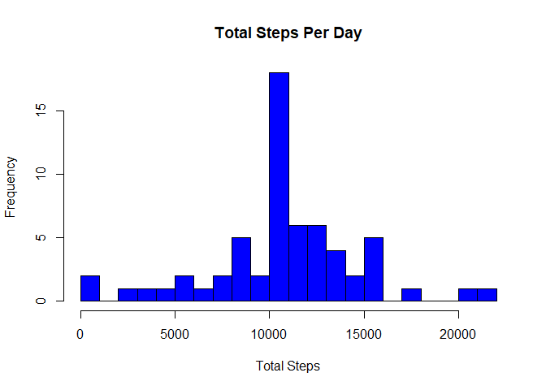

```r
    hist(totalStepsByDayNew$total_steps,
         breaks=30,
         xlab="Total Steps",
         main="Total Steps Per Day",
         col="blue")
```

- Calculate the mean and median number of steps per day for the new values

```r
    stepsByDayMeanNew <- mean(totalStepsByDayNew$total_steps)
    stepsByDayMedianNew <- median(totalStepsByDayNew$total_steps)
```

## Are there differences in activity patterns between weekdays and weekends?

- Create a new factor variable in the dataset with two levels - “weekday” and “weekend” indicating whether a given date is a weekday or weekend day

```r
  Sys.setlocale(category = "LC_ALL", locale = "english")
```

```
## [1] "LC_COLLATE=English_United States.1252;LC_CTYPE=English_United States.1252;LC_MONETARY=English_United States.1252;LC_NUMERIC=C;LC_TIME=English_United States.1252"
```

```r
  activityNew$weekday <- weekdays(activityNew$date)
  activityNew$weekend_indicator <- as.factor(apply(activityNew["weekday"], 1,
    function(x) { switch(x, "Sunday" = "weekend", "Saturday" = "weekend", "weekday")}))
```

- Make a panel plot containing a time series plot comparing activity patterns on weekdays and weekends

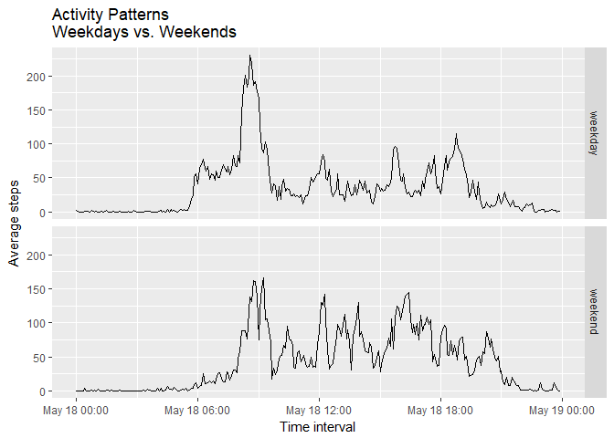

```r
    averageStepsByTimeWeekend <- aggregate(list(average_steps = activityNew$steps),
        by = list(time = activityNew$time.x, daytype = activityNew$weekend_indicator),
        FUN = mean)

    library(ggplot2)
    qplot(x = time,
          y = average_steps,
          geom="path",
          data = averageStepsByTimeWeekend,
          xlab="Time interval",
          ylab="Average steps",
          main="Activity Patterns\nWeekdays vs. Weekends",
          facets = daytype ~ .)
```